# MSDM5004 Part II Assignment 1 Solution

```python
import numpy as np
import matplotlib.pyplot as plt
from scipy.fft import rfft, rfftfreq
```

## Q1

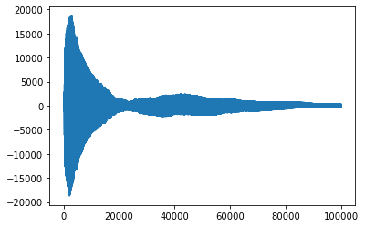

```python
piano_txt = open("piano.txt", "r")

piano_data = piano_txt.read().split('\n')[:-1]
piano_data = [int(i) for i in piano_data]

piano_txt.close()

plt.plot(piano_data)
plt.show()
```

```
Frequency with the max coefficient:  525.231
```

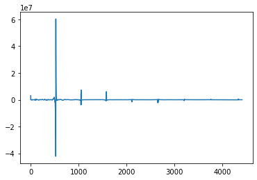

```python
sample_rate = 44100
piano_fft = np.real(rfft(piano_data))
piano_freq = rfftfreq(len(piano_data), d=1./sample_rate)

print("Frequency with the max coefficient: ", piano_freq[np.argmax(piano_fft)])

plt.plot(piano_freq[:10000], piano_fft[:10000])
plt.show()
```

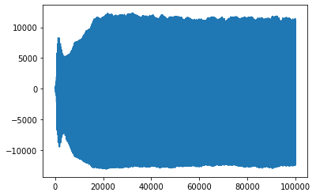

```python
trumpet_txt = open("trumpet.txt", "r")

trumpet_data = trumpet_txt.read().split('\n')[:-1]
trumpet_data = [int(i) for i in trumpet_data]

trumpet_txt.close()

plt.plot(trumpet_data)
plt.show()
```

```
Frequency with the max coefficient:  1043.847
```

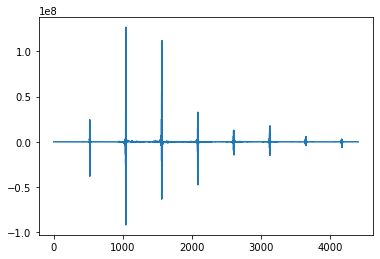

```python
sample_rate = 44100
trumpet_fft = np.real(rfft(trumpet_data))
trumpet_freq = rfftfreq(len(trumpet_data), d=1./sample_rate)

print("Frequency with the max coefficient: ", trumpet_freq[np.argmax(trumpet_fft)])

plt.plot(trumpet_freq[:10000], trumpet_fft[:10000])
plt.show()
```

## Q2

#### The original sequence

```
[1 1 1 0 0 0 0 0 1 2 0 2 1 0 0 2 1 1]
```

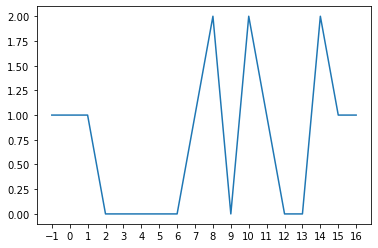

```python
n = np.arange(-1, 17)
gn = np.array([(1 if i in [-1,0,1,7,11,15,16] else 2 if i in [8,10,14] else 0) for i in n])

print(gn)
plt.plot(n, gn)
plt.xticks(n)
plt.show()
```

#### After applying linear convolution

```
[2.0, 1.5, 0.5, 0.0, 0.0, 0.0, 0.5, 2.0, 2.5, 2.0, 2.5, 2.0, 0.5, 1.0, 2.5, 2.5]
```

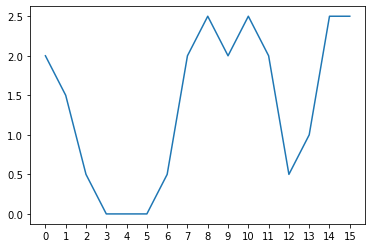

```python
hn = np.array([0.5,1,0.5])

yn = [np.dot(hn, gn[i:i+len(hn)]) for i in range(len(gn)-len(hn)+1)]

print(yn)
plt.plot(n[1:-1], yn)
plt.xticks(n[1:-1])
plt.show()
```

#### Deconvolute by FFT/iFFT

The spirit of FFT on a sequence of length $M=2^n$ is that we only need to compute once the factors $\exp{\left(\frac{2\pi ik}{M}\right)}$ for $k=0$ to $\frac{M}{2}$, and keep reusing them at each subsequent level. This is possible because of the properties:

$$ \begin{align*} \exp{\left(\frac{2\pi i k}{\frac{M}{2}}\right)} &= \exp{\left(\frac{2\pi i(2k)}{M}\right)} \\[1.1em] \exp{\left(\frac{2\pi i\left(k+\frac{M}{2}\right)}{M}\right)} &= \exp{\left(\frac{2\pi ik}{M}+i\pi\right)} = - \exp{\left(\frac{2\pi ik}{M}\right)} \end{align*} $$

```python
# only works for sequence of length M=2^n

def FFT(seq, inverse=False):

    M = len(seq)
    if inverse:
        W = np.exp(-1j*2*np.pi/M*np.arange(M//2))
    else:
        W = np.exp(1j*2*np.pi/M*np.arange(M//2))

    def FFT_recursive(seq):
        L = len(seq)
        while L > 2:

            H0 = FFT_recursive(seq[::2])
            H1 = FFT_recursive(seq[1::2])

            return np.concatenate((H0+W[::M//L]*H1, H0-W[::M//L]*H1))

        return np.array([seq[0]+seq[1], seq[0]-seq[1]])

    return FFT_recursive(seq)/M if inverse else FFT_recursive(seq)
```

The 16-periodic sequence of $h$ is simply $[1, 0.5, 0, ..., 0, 0.5]$ (13 zeros in the middle).

```python
hn = np.array([(1 if i==0 else 0.5 if i in [1,15] else 0) for i in range(len(yn))])
print(hn)
```

```
[1.  0.5 0.  0.  0.  0.  0.  0.  0.  0.  0.  0.  0.  0.  0.  0.5]
```

Perform FFT on $h$ and $y$

```python
Hn = FFT(hn)
print(Hn)
```

```
[2.        +0.00000000e+00j 1.92387953+0.00000000e+00j
 1.70710678-5.55111512e-17j 1.38268343-2.77555756e-17j
 1.        +0.00000000e+00j 0.61731657-2.77555756e-17j
 0.29289322+5.55111512e-17j 0.07612047+1.11022302e-16j
 0.        +0.00000000e+00j 0.07612047+0.00000000e+00j
 0.29289322+5.55111512e-17j 0.61731657+2.77555756e-17j
 1.        +0.00000000e+00j 1.38268343+2.77555756e-17j
 1.70710678-5.55111512e-17j 1.92387953-1.11022302e-16j]
```

```python
Yn = FFT(yn)
print(Yn)
```

```
[22.        +0.00000000e+00j -0.88268343-6.48274915e+00j
  7.53553391+0.00000000e+00j  0.42387953-2.10425636e+00j
 -1.        -2.00000000e+00j -1.42387953+2.55259789e+00j
  0.46446609+2.22044605e-16j -0.11731657+1.74105095e-01j
  0.        +0.00000000e+00j -0.11731657-1.74105095e-01j
  0.46446609+0.00000000e+00j -1.42387953-2.55259789e+00j
 -1.        +2.00000000e+00j  0.42387953+2.10425636e+00j
  7.53553391-2.22044605e-16j -0.88268343+6.48274915e+00j]
```

By convolution theorem, $\mathcal{F}(g) = \frac{\mathcal{F}(y)}{\mathcal{F}(h)}$. Then we can recover $g$ by iFFT.

```python
g_prime = FFT(Yn/(Hn+1E-15), inverse=True)
print(np.real(g_prime))
```

```
[ 0.8125  1.1875 -0.1875  0.1875 -0.1875  0.1875 -0.1875  1.1875  1.8125
  0.1875  1.8125  1.1875 -0.1875  0.1875  1.8125  1.1875]
```

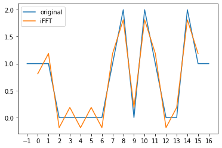

```python
plt.plot(n, gn, label="original")
plt.plot(n[1:-1], np.real(g_prime), label="iFFT")
plt.xticks(n)
plt.legend(loc=0)
plt.show()
```

## Q3

**Note:** The given boundary conditions are NOT periodic because the functions at $y=0$ and $y=2$ are not the same.

```python
Delta = 0.01
x = np.arange(0,1+Delta,Delta)
y = np.arange(0,2+Delta,Delta)

J = len(x)-1
L = len(y)-1

j = np.arange(1,J)    # not include values at boundary
l = np.arange(1,L)

m = np.arange(1,J)
n = np.arange(1,L)
```

The boundary condition $\phi(x,y=2)=\cos\left(\frac{\pi x}{2}\right)$ is inhomogeneous. So the first thing to do is to modify the source from $\rho_{j,L-1}=0$ to $\rho_{j,L-1}=0-\frac{f_j}{\Delta^2}$ (while anywhere else remains $0$).

```python
# compute rho_jl. Modify the edge J-1 to match the boundary condition.
f_j = np.cos(np.pi/2*j*Delta)
rho = np.zeros((J-1, L-1))
rho[:,-1] = -f_j

# perform DST on rho
rho_mn = np.einsum("jl, jm, ln -> mn", rho, np.sin(np.pi*np.outer(j, m)/J), np.sin(np.pi*np.outer(l, n)/L))
```

Then solve the Laplace's equation by DST.

$$\phi_{j+1,l}+\phi_{j-1,l}+\phi_{j,l+1}+\phi_{j,l-1}-4\phi_{j,l} = \rho_{j,l}\Delta^2$$$$\Downarrow$$$$\tilde{\phi}_{mn} = \frac{\tilde{\rho}_{mn}\Delta^2}{2\left(\cos\left(\frac{\pi m}{J}\right)+\cos\left(\frac{\pi n}{L}\right)-2\right)}$$

```python
# compute phi_mn
M,N = np.meshgrid(m, n, indexing='ij')
denom = 2*(np.cos(np.pi*M/J) + np.cos(np.pi*N/L)-2)

phi_mn = np.divide(rho_mn, denom, out=np.zeros_like(rho_mn), where=(denom != 0))
```

Finally inverse DST the results.

```python
# compute phi_il
phi_jl = np.einsum("mn, jm, ln -> jl", phi_mn, np.sin(np.pi*np.outer(j, m)/J), np.sin(np.pi*np.outer(l, n)/L))*4/J/L
```

```python
# append values at boundary
X, Y = np.meshgrid(x, y, indexing='ij')
phi = np.zeros_like(X)
phi[1:-1, 1:-1] = phi_jl
phi[1:-1,-1] = f_j
```

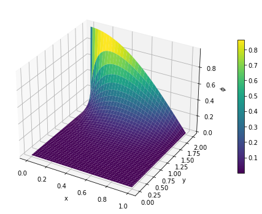

```python
fig = plt.figure(figsize=[8, 8])
ax = plt.axes(projection='3d')

surf = ax.plot_surface(X, Y, phi, cmap="viridis")
ax.set_xlabel("x")
ax.set_ylabel("y")
ax.set_zlabel(r"$\phi$")
fig.colorbar(surf, shrink=0.5, pad=0.1)

plt.show()
```